# CryptoInvestments

Jay Chudasama

12/10/2021

## BACKGROUND AND INSPIRATION

With a total crypto market cap of $2,263,042,161,49424 (coinmarketcap.com) and with over 15,501 cryto coins. Should regular investors invest in crypto as part of their overall portfolio? Being relative new in this space, should regular investors invest in crypto to improve their overall portfolio performance relative to invetment risk.

## PROJECT GOALS

Should regular individual investors invest in Crypto space?

## DATA ANALYSIS

There are over 15,000 crypto coins to invest in and with the data set being so large. I decided only to look at 10 stable coins vs alt (alternative) coins. I was able to find a recent dataset from Kaggle (https://www.kaggle.com/nward7/popular-cryptocurrency-historical-data) that provided historical prices for 10 stable coins.

Data Dictionary:

- Date Date of observation
- Open Opening price on the given day
- High Highest price on the given day
- Low Lowest price on the given day
- Close Closing price on the given day
- Volume Volume of transactions on the given day
- Market Cap Market capitalization
- Coin Crypto Coin [Added]

## DATA ANALYSIS

### Data Load:

Before running any data analysis against the kaggle data set, I first needed to stitch the crypto historical files including added feature variables such at Mid Price, Coin, etc.

Crypto coins in scope of data analysis:

```
##        Coin
## 1       BNB
## 2       BTC
## 3   Cardano
## 4       ETH
## 5  Polkadot
## 6    Solana
## 7     Terra
## 8    Tether
## 9       USD
## 10      XRP
```

Running a quick analysis, the mean price for BTC (Bitcoin) was $8,952, followed by ETH (Etherem) at $901 with Binance (BNB) averaging $102.

```
## # A tibble: 10 × 2
##    Coin         mean
##    <fct>       <dbl>
##  1 BTC      8952.
##  2 ETH       902.
##  3 BNB       102.
##  4 Solana     42.3
##  5 Polkadot   23.3
##  6 Terra       8.13
##  7 USD         1.01
##  8 Tether      1.01
##  9 XRP         0.541
## 10 Cardano     0.463
```

The total market cap as of 12/01/2021 was $2.071986e+12 for the 10 coins. This is huge number and money invested in the crypto market.

```
## # A tibble: 3,140 × 2
##    Date          Market.Cap
##    <date>             <dbl>
##  1 2021-12-01 2071986042929
##  2 2021-11-30 2064840368831
##  3 2021-11-29 2053818898304
##  4 2021-11-28 2018475504147
##  5 2021-11-27 1939230044033
##  6 2021-11-26 1900773350533
##  7 2021-11-25 2018735702648
##  8 2021-11-24 1997211916532
##  9 2021-11-23 2042430578633
## 10 2021-11-22 1978819231371
## # … with 3,130 more rows
```

As the number of coins have increased, demand for coins increased which confirms the increased market cap over time.

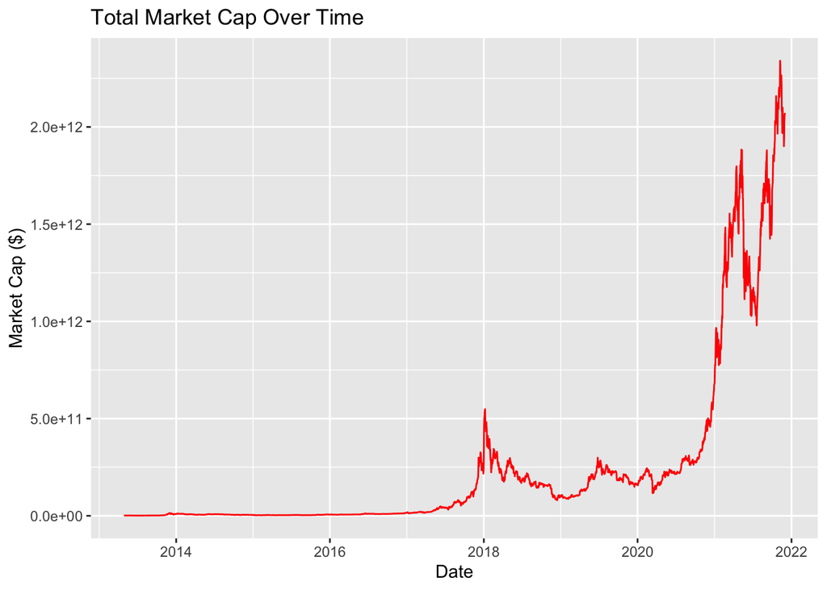

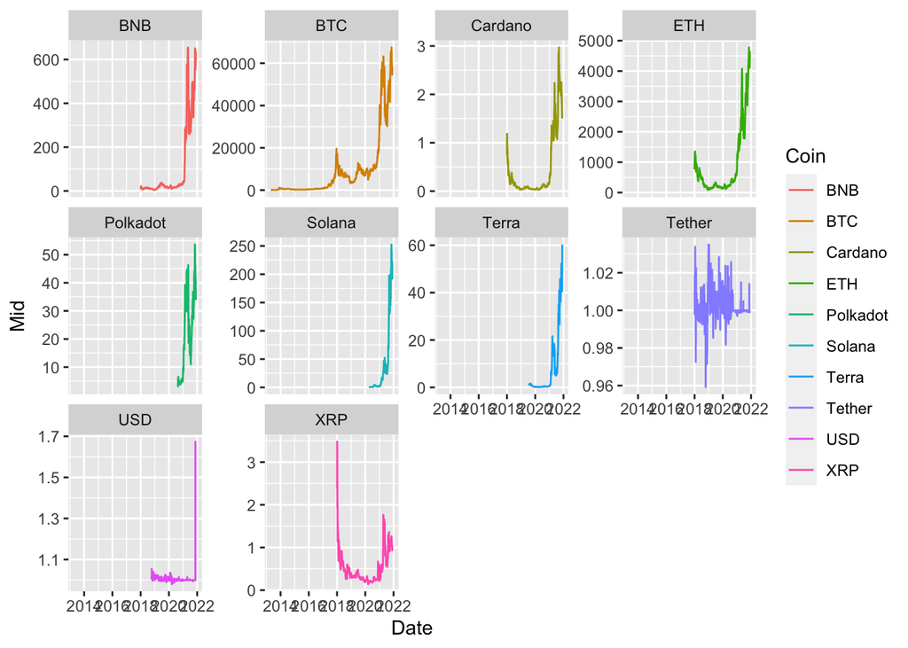

Lets now take a closer look and the daily returns for each coin. As per the charts, you can generally see each coin is very volatile. For example, BTC daily extremes were +/- 20%. BNB (Binance) saw daily extremes such as 50%. Lets now look at yearly returns.

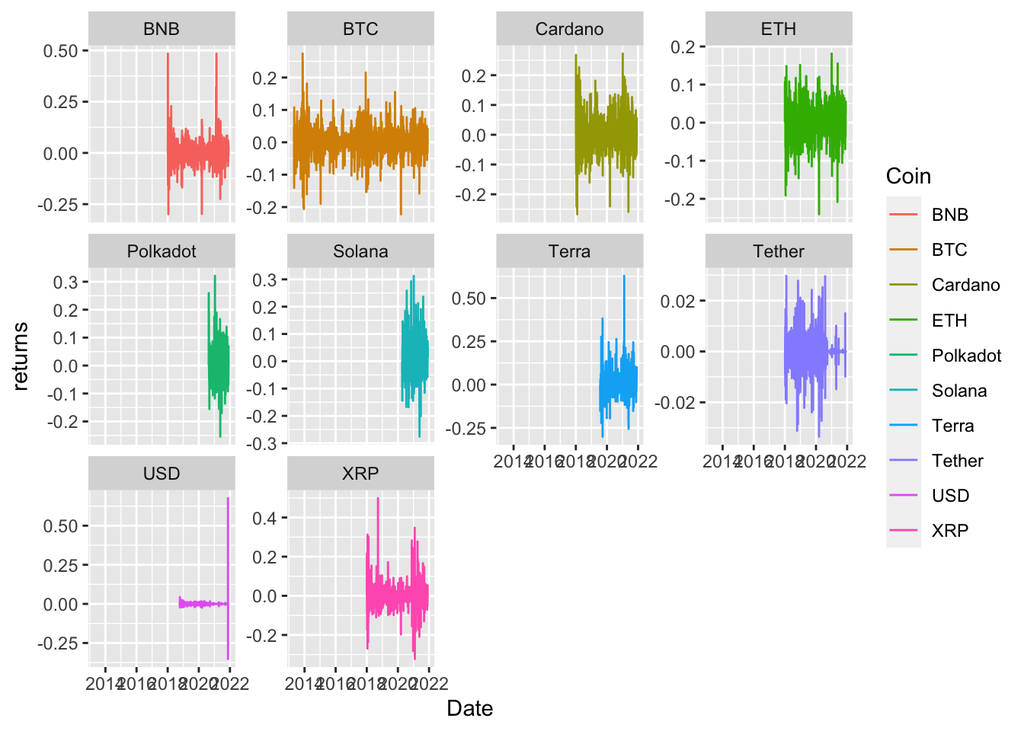

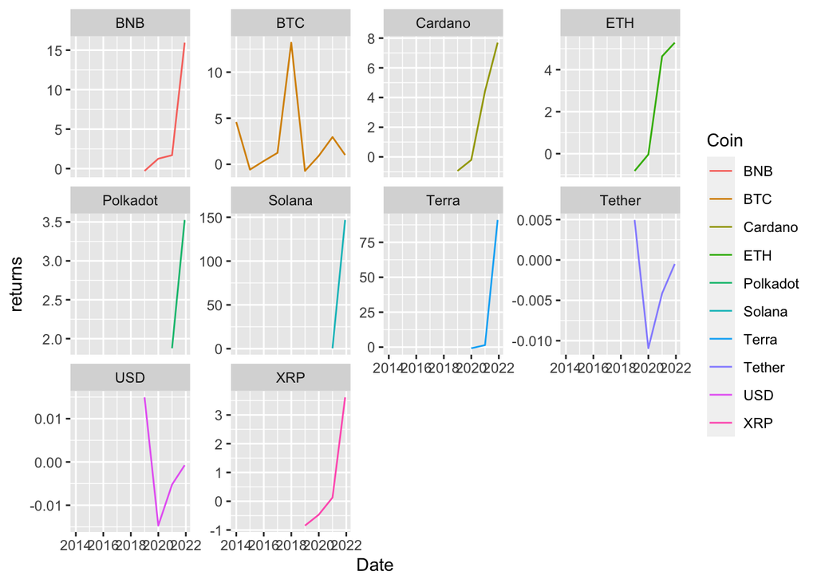

Like with any investment, we can see volatility in returns. Let’s now take a closer look at the standard deviation for each coin returns. In general, many of the coins demonstrated volatility in returns with a standard deviation for BNB at 7.6x with BTC at 4.3x.

```
## # A tibble: 10 × 3
##    Coin         mean        sd
##    <fct>       <dbl>     <dbl>
##  1 BNB       4.65      7.58
##  2 BTC       2.55      4.33
##  3 Cardano   2.74      4.07
##  4 ETH       2.27      3.14
##  5 Polkadot  2.70      1.17
##  6 Solana   73.7     103.
##  7 Terra    30.5      52.4
##  8 Tether   -0.00265   0.00666
##  9 USD      -0.00144   0.0124
## 10 XRP       0.606     2.04
```

As a suitable comparison, lets now compare the BTC returns (inc volatility) with the S&P500. From the data, you can see BTC yielded on average 255% with a standard deviation of 432%. While sp500 during the same period yielded 14% with a standard deviation of returns of 12%.

```
## # A tibble: 9 × 4
## # Groups:   Coin [1]
##   Coin  Date       returns   sp500
##   <fct> <date>       <dbl>   <dbl>
## 1 BTC   2013-12-31   4.59   0.296
## 2 BTC   2014-12-31  -0.579  0.114
## 3 BTC   2015-12-31   0.351 -0.0073
## 4 BTC   2016-12-31   1.24   0.0954
## 5 BTC   2017-12-31  13.2    0.194
## 6 BTC   2018-12-31  -0.720 -0.0624
## 7 BTC   2019-12-31   0.910  0.289
## 8 BTC   2020-12-31   2.96   0.163
## 9 BTC   2021-12-01   1.01   0.243
```

```
## # A tibble: 1 × 5
##   Coin  `mean(returns)` `sd(returns)` `mean(sp500)` `sd(sp500)`
##   <fct>           <dbl>         <dbl>         <dbl>       <dbl>
## 1 BTC              2.55          4.33         0.147       0.125
```

Next is there a diversification benefit investing in crypto relative to the S&P500. With a correlation of 0.38, the returns are correlated to the S&P. Therefore, there doesn’t seem to be a diversification benefit investing in crypto.

```
## [1] 0.375838
```

## CONCLUSION

In summary, should investors (included myself) invest in Crypto? The overall price appreciation across the 10 coins does yield greater returns but these returns are very volatile. However, these high returns are correlated to the S&P and hence offer little diversification benefits. But I do believe investing a small portion of your overall portfolio may provide improved returns. However, like with any investment, the appropriate research needs to be carried out and more importantly the loss recovery in case the crypto market tanks.

## FUTURE WORK

This analysis was fairly simplistic. To expand my analysis, I would spend time researching if there’s an optimal portfolio that includes BTC, Risk Free, Stock, and Bonds. In other words, a portfolio on the efficient frontier. In addition, this analysis does not cover alt coins which are a large part of the crypto space with very extreme volatilities.